# Statistical Learning - Exam Assignmet

Filippo Monaco

25.01.2024

The goal of this project is to predict if a person is ill (class 1) or not (class 0), based on health characteristics. Three different classification models are showcased and the final result will be obtained using a Balanced Logarithmic Loss.

# Data

## Data Loading

First, data needs to be uploaded.

There is a Training dataset (‘train.csv’) and Testing dataset (‘test.csv’).

```r
library(tidyverse)

# load dataframe
df_train <- read.csv("train.csv")
```

## Dataset Inspection

Inspect first few rows of the training dataframe.

```r
head(df_train)
```

```
##     X           Id       AB       AF        AH       AM        AR       AX
## 1 376 91275f6ae0a2 0.474303 2465.484 160.30656 14.60855 11.636436 4.128294
## 2 518 d10976c44b2b 0.316202 1624.694 145.01356 14.14710  8.138688 7.206797
## 3 436 acd97f3380e4 0.692226 2709.134 124.73030 30.18956  8.138688 6.896731
## 4 577 ed3486389307 0.517033 3749.952  97.14019 14.98019  8.138688 4.358628
## 5 361 8c58bec30f78 0.273472 8941.841  85.20015 51.51550 12.892374 7.184649
## 6 171 43365f867d38 0.807597 2174.835  89.76802 88.54633 17.908260 6.032979
##          AY       AZ        BC       BD      BN       BP        BQ        BR
## 1 0.1120560  6.14445  6.290060 4251.655 20.8329 134.3763        NA 1805.2394
## 2 0.0255780 11.40032  1.229900 5012.662 19.4205 175.7489        NA  590.1828
## 3 0.0487200 20.27984  1.229900 6066.455 22.2453 334.7072  53.77502 1248.1476
## 4 0.0377580 15.89364  4.687676 5694.429 16.2426 240.3322  22.07998 4779.3996
## 5 0.0417165 10.07060  1.229900 4874.403 21.5391 221.9880 344.64411 2641.8161
## 6 0.2369010 13.84864 11.416986 4854.540 26.4825 277.6842 214.45141 1186.8834
##          BZ        CB        CC        CD        CF       CH       CL       CR
```

[output cut: 41 more lines]

```r
dim(df_train)
```

```
## [1] 555  59
```

The training dataset is composed of 555 observations, each with 56 variables, since the first two are the index and the numeric Id (which can both be discarded), and the last one is actually the response (which will need to be removed before model fitting).

Remove the X and Id variables.

```r
df_train <- select(df_train, -c(X,Id))
```

Now print a summary of all the variables.

```r
summary(df_train)
```

```
##        AB                AF                AH               AM
##  Min.   :0.08119   Min.   :  192.6   Min.   :  85.2   Min.   :  3.178
##  1st Qu.:0.25211   1st Qu.: 2220.4   1st Qu.:  85.2   1st Qu.: 12.066
##  Median :0.35466   Median : 3109.0   Median :  85.2   Median : 20.301
##  Mean   :0.47345   Mean   : 3544.0   Mean   : 118.4   Mean   : 39.032
##  3rd Qu.:0.54694   3rd Qu.: 4420.4   3rd Qu.: 112.3   3rd Qu.: 40.346
##  Max.   :6.16167   Max.   :28688.2   Max.   :1910.1   Max.   :630.518
##
##        AR                AX                AY                 AZ
##  Min.   :  8.139   Min.   : 0.6999   Min.   : 0.02558   Min.   : 3.397
##  1st Qu.:  8.139   1st Qu.: 4.1194   1st Qu.: 0.02558   1st Qu.: 8.104
##  Median :  8.139   Median : 5.0231   Median : 0.02558   Median :10.487
##  Mean   : 10.123   Mean   : 5.4743   Mean   : 0.06210   Mean   :10.556
##  3rd Qu.:  8.139   3rd Qu.: 6.3696   3rd Qu.: 0.03608   3rd Qu.:12.944
##  Max.   :178.944   Max.   :17.9838   Max.   :10.31585   Max.   :38.972
##
##        BC                 BD              BN               BP
##  Min.   :   1.230   Min.   : 1694   Min.   : 9.887   Min.   :  85.17
##  1st Qu.:   1.230   1st Qu.: 4177   1st Qu.:19.421   1st Qu.: 156.99
##  Median :   1.230   Median : 4988   Median :21.186   Median : 194.58
##  Mean   :   8.511   Mean   : 5377   Mean   :21.451   Mean   : 228.53
##  3rd Qu.:   5.021   3rd Qu.: 6029   3rd Qu.:23.834   3rd Qu.: 252.39
##  Max.   :1463.693   Max.   :53061   Max.   :29.307   Max.   :1671.79
##
##        BQ                BR                  BZ                CB
##  Min.   :  1.331   Min.   :    51.22   Min.   :  257.4   Min.   :  12.50
##  1st Qu.: 28.582   1st Qu.:   421.08   1st Qu.:  257.4   1st Qu.:  23.60
##  Median : 64.703   Median :   615.85   Median :  257.4   Median :  42.80
##  Mean   :100.896   Mean   :  1239.79   Mean   :  550.1   Mean   :  74.04
##  3rd Qu.:135.582   3rd Qu.:   951.09   3rd Qu.:  257.4   3rd Qu.:  78.50
##  Max.   :344.644   Max.   :179250.25   Max.   :50092.5   Max.   :1835.20
##  NA's   :50                                              NA's   :1
##        CC               CD               CF                 CH
##  Min.   :0.1769   Min.   : 23.39   Min.   :  0.5109   Min.   :0.003184
##  1st Qu.:0.5621   1st Qu.: 64.48   1st Qu.:  5.2366   1st Qu.:0.023482
##  Median :0.6569   Median : 79.56   Median :  9.1306   Median :0.028258
##  Mean   :0.6876   Mean   : 89.77   Mean   : 11.4716   Mean   :0.030671
##  3rd Qu.:0.7719   3rd Qu.: 98.95   3rd Qu.: 13.6662   3rd Qu.:0.034527
##  Max.   :4.1030   Max.   :633.53   Max.   :200.9675   Max.   :0.224074
##  NA's   :2
```

[output cut: 65 more lines]

```
##  Min.   :    13.04   Min.   : 9.433   Min.   :  0.8976   Min.   : 0.001129
##  1st Qu.:  2841.47   1st Qu.:25.113   1st Qu.: 23.0695   1st Qu.: 0.124273
##  Median :  7727.94   Median :30.680   Median : 41.7564   Median : 0.331320
##  Mean   : 14087.58   Mean   :31.578   Mean   : 51.2408   Mean   : 8.469614
##  3rd Qu.: 18756.12   3rd Qu.:37.217   3rd Qu.: 68.4139   3rd Qu.:21.978000
##  Max.   :134409.54   Max.   :81.211   Max.   :191.1948   Max.   :21.978000
##                                                          NA's   :1
##      Class
##  Min.   :0.0000
##  1st Qu.:0.0000
##  Median :0.0000
##  Mean   :0.1784
##  3rd Qu.:0.0000
##  Max.   :1.0000
##
```

All variables are numeric, except for EJ.

We can convert it into a factor variable.

```r
df_train$EJ <- as.factor(df_train$EJ)
```

We can also check the distribution of the target variables (Class).

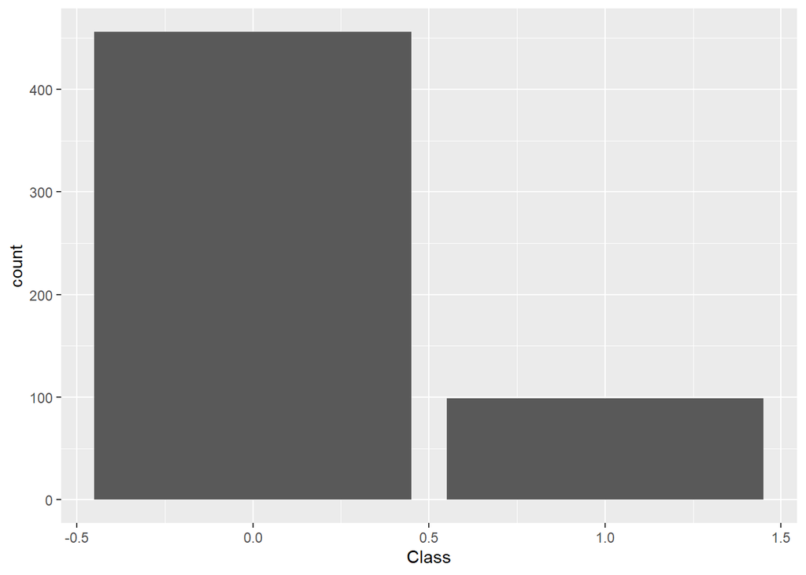

```r
library(ggplot2)
ggplot(data = df_train, aes(x = Class)) + geom_bar()
```

The response is very skewed towards 0. This means that we are dealing with an unbalanced dataset, since most observations are of class 0. This is a problem that will need to be dealt with later on.

We can also study the relationship between pairs of predictors, but since we don’t know what the predictors actually are, we can only plot random pairs together in hope of finding some pattern in the data.

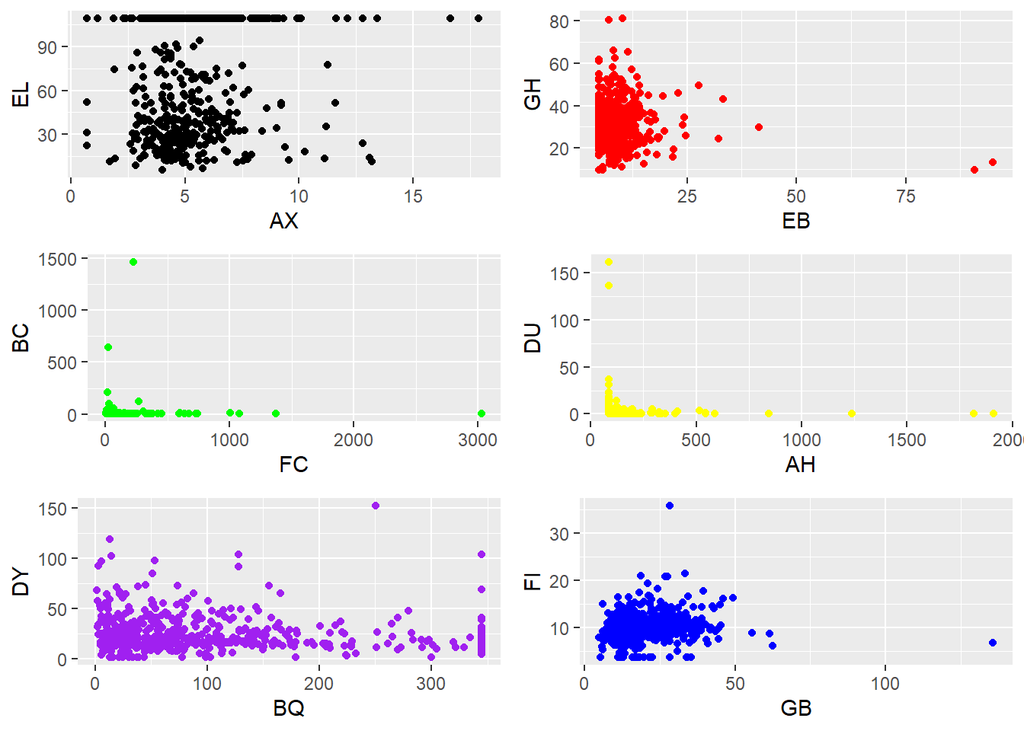

```r
library(gridExtra)
p1 <- ggplot(df_train, aes(x = AX, y = EL)) +  geom_point(color="black")
p2 <- ggplot(df_train, aes(x = EB, y = GH)) +  geom_point(color="red")
p3 <- ggplot(df_train, aes(x = FC, y = BC)) +  geom_point(color="green")
p4 <- ggplot(df_train, aes(x = AH, y = DU)) +  geom_point(color="yellow")
p5 <- ggplot(df_train, aes(x = BQ, y = DY)) +  geom_point(color="purple")
p6 <- ggplot(df_train, aes(x = GB, y = FI)) +  geom_point(color="blue")
grid.arrange(p1, p2, p3, p4, p5, p6, nrow = 3)
```

These plots don’t provide any additional information, since complete enumeration is impossible.

## Missing Values

We will now take a closer look at the dataset and see if there are any missing values.

```r
library(finalfit)
library(visdat)
library(naniar)
ff_glimpse(df_train)
```

```
## $Continuous
##       label var_type   n missing_n missing_percent    mean      sd    min
## AB       AB    <dbl> 555         0             0.0     0.5     0.5    0.1
## AF       AF    <dbl> 555         0             0.0  3544.0  2325.4  192.6
## AH       AH    <dbl> 555         0             0.0   118.4   132.6   85.2
## AM       AM    <dbl> 555         0             0.0    39.0    71.1    3.2
## AR       AR    <dbl> 555         0             0.0    10.1    11.0    8.1
## AX       AX    <dbl> 555         0             0.0     5.5     2.2    0.7
## AY       AY    <dbl> 555         0             0.0     0.1     0.4    0.0
## AZ       AZ    <dbl> 555         0             0.0    10.6     4.4    3.4
## BC       BC    <dbl> 555         0             0.0     8.5    68.7    1.2
## BD       BD    <dbl> 555         0             0.0  5377.1  3139.1 1693.6
## BN       BN    <dbl> 555         0             0.0    21.5     3.5    9.9
## BP       BP    <dbl> 555         0             0.0   228.5   153.2   85.2
## BQ       BQ    <dbl> 505        50             9.0   100.9    97.7    1.3
## BR       BR    <dbl> 555         0             0.0  1239.8  7980.6   51.2
## BZ       BZ    <dbl> 555         0             0.0   550.1  2177.9  257.4
## CB       CB    <dbl> 554         1             0.2    74.0   134.6   12.5
## CC       CC    <dbl> 553         2             0.4     0.7     0.3    0.2
## CD       CD    <dbl> 555         0             0.0    89.8    51.8   23.4
## CF       CF    <dbl> 555         0             0.0    11.5    14.1    0.5
## CH       CH    <dbl> 555         0             0.0     0.0     0.0    0.0
## CL       CL    <dbl> 555         0             0.0     1.4     2.0    1.1
## CR       CR    <dbl> 555         0             0.0     0.7     0.3    0.1
## CS       CS    <dbl> 555         0             0.0    37.0    17.8   13.8
## CU       CU    <dbl> 555         0             0.0     1.4     0.5    0.1
## CW       CW    <dbl> 555         0             0.0    27.3    14.7    7.0
## DA       DA    <dbl> 555         0             0.0    51.3    21.4    6.9
## DE       DE    <dbl> 555         0             0.0   403.3   314.3   36.0
## DF       DF    <dbl> 555         0             0.0     0.6     2.0    0.2
## DH       DH    <dbl> 555         0             0.0     0.4     0.1    0.0
## DI       DI    <dbl> 555         0             0.0   146.9    88.1   60.2
## DL       DL    <dbl> 555         0             0.0    94.7    29.0   10.3
## DN       DN    <dbl> 555         0             0.0    26.4     8.0    6.3
## DU       DU    <dbl> 554         1             0.2     1.9     9.5    0.0
## DV       DV    <dbl> 555         0             0.0     1.9     1.6    1.7
## DY       DY    <dbl> 555         0             0.0    26.5    18.3    0.8
## EB       EB    <dbl> 555         0             0.0     9.1     6.4    4.9
## EE       EE    <dbl> 555         0             0.0     3.1     2.0    0.3
## EG       EG    <dbl> 555         0             0.0  1735.6  1845.8  185.6
```

[output cut: 66 more lines]

```
## FR            0.5    1.1         1.5   1244.2
## FS            0.1    0.3         0.5     31.4
## GB           14.0   18.7        25.6    135.8
## GE           72.6   72.6       128.5   1497.4
## GF         2841.5 7727.9     18756.1 134409.5
## GH           25.1   30.7        37.2     81.2
## GI           23.1   41.8        68.4    191.2
## GL            0.1    0.3        22.0     22.0
## Class         0.0    0.0         0.0      1.0
##
## $Categorical
##    label var_type   n missing_n missing_percent levels_n                levels
## EJ    EJ    <fct> 555         0             0.0        2 "A", "B", "(Missing)"
##    levels_count levels_percent
## EJ     198, 357         36, 64
```

We can see that there are multiple missing values for the following predictors:

BQ, CB, CC, DU, EL, FC, FL, FS, GL.

We can use a HEATMAP to take a closer look at the missing values for each of these predictors.

Since there is a limited amount of both observations (<1000) and predictors (<100), there is no need to apply a dimensionality reduction technique (such as PCA).

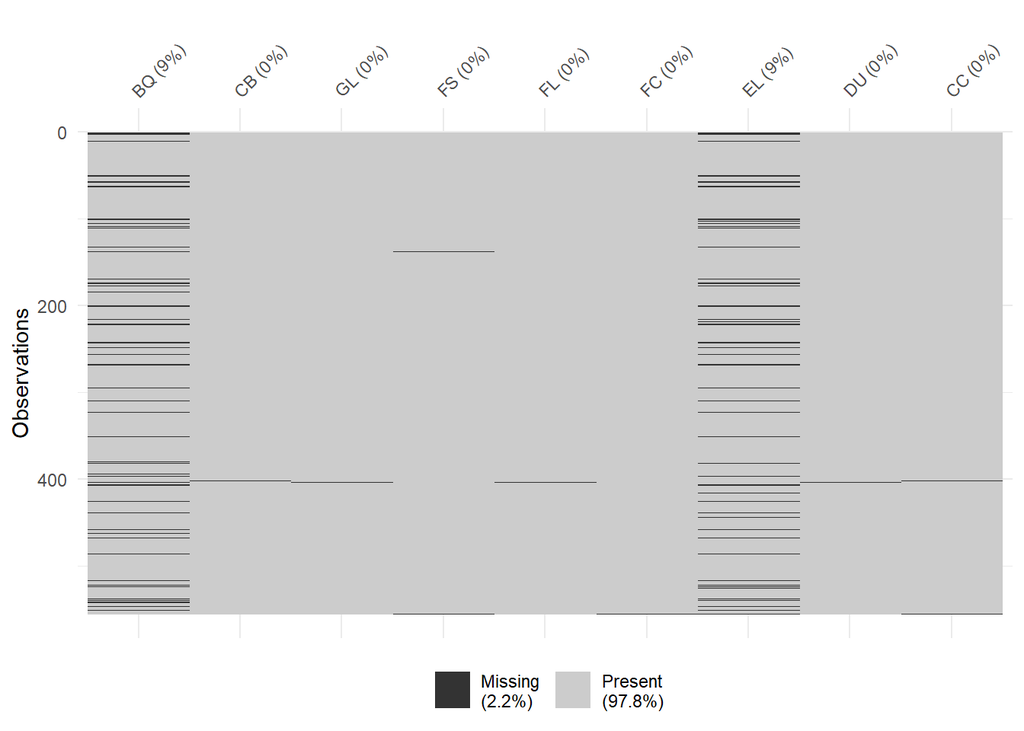

```r
df_train %>% select(BQ, CB, GL, FS, FL, FC, EL, DU, CC) %>% vis_miss()
```

We can also use a CO-OCCURRENCES PLOT, which can tell us more about missing values for different predictor combinations.

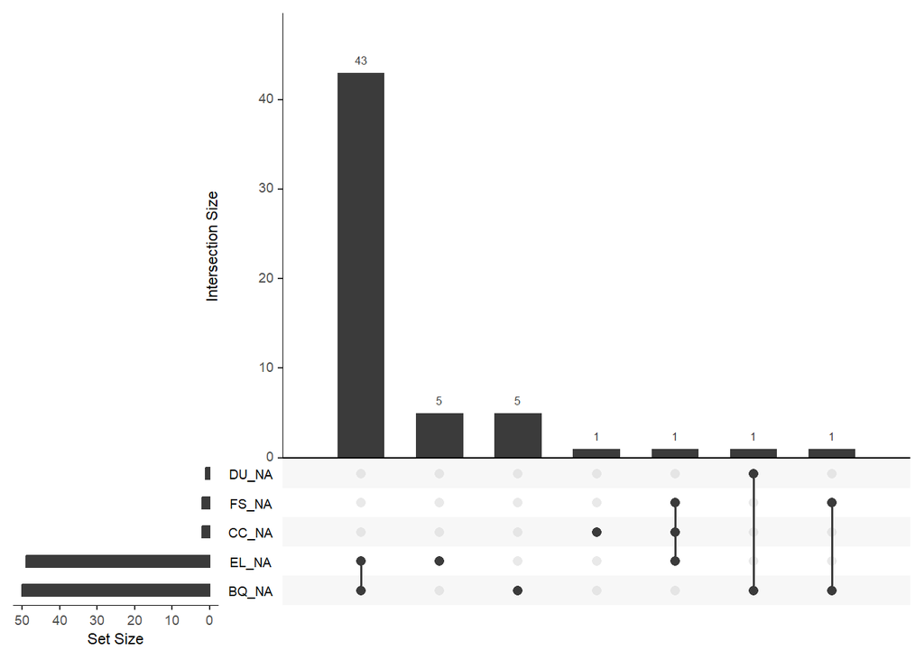

```r
df_train %>% select(BQ, CB, GL, FS, FL, FC, EL, DU, CC) %>% gg_miss_upset()
```

We can see that variables EL and BQ share 43 missing values, while the other variables only have a couple of NA’s.

Let’s study in more depth the relationship between EL and BQ, by plotting the two variables.

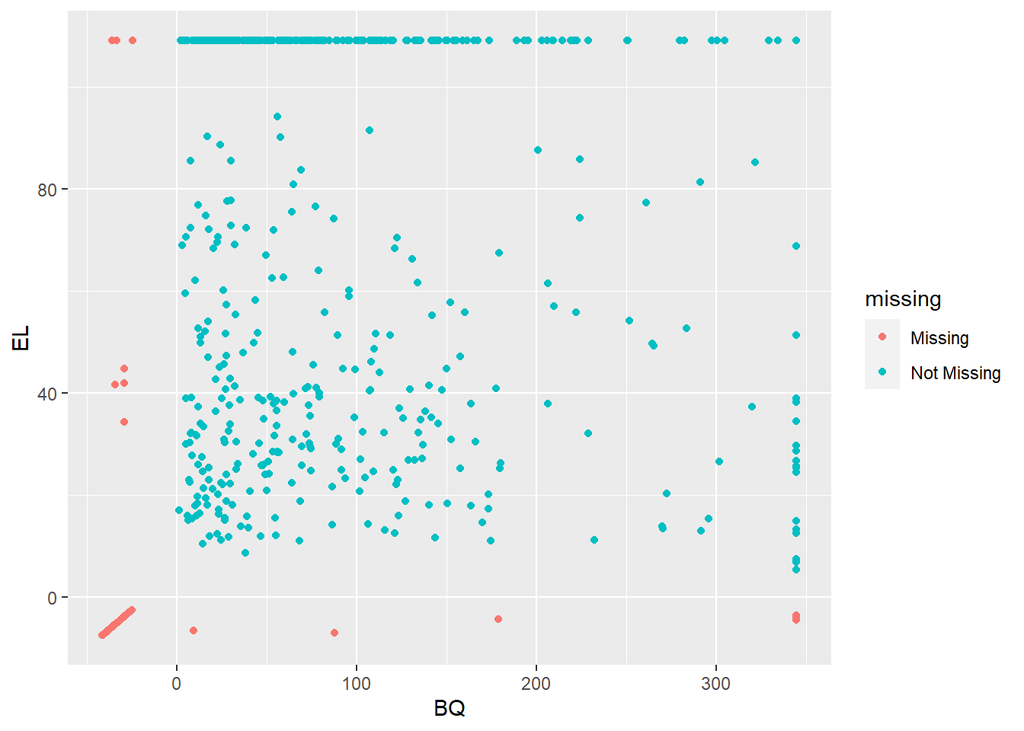

```r
ggplot(df_train, aes(x = BQ, y = EL)) + geom_miss_point()
```

We can clearly see that missing values are present when one of the two variables has low values, or when they both have low values.

Since we have no knowledge on what the variables actually mean, we can only say that the missing values are due to random occurrence, and, in particular, are Missing at Random (MAR).

We can thus replace all the missing values with the median value of that specific predictor.

```r
df_train <- df_train %>% mutate(across(where(is.numeric), ~replace_na(., median(., na.rm=TRUE))))
```

If we now plot the heatmap of missing values, we can clearly see that now there are none.

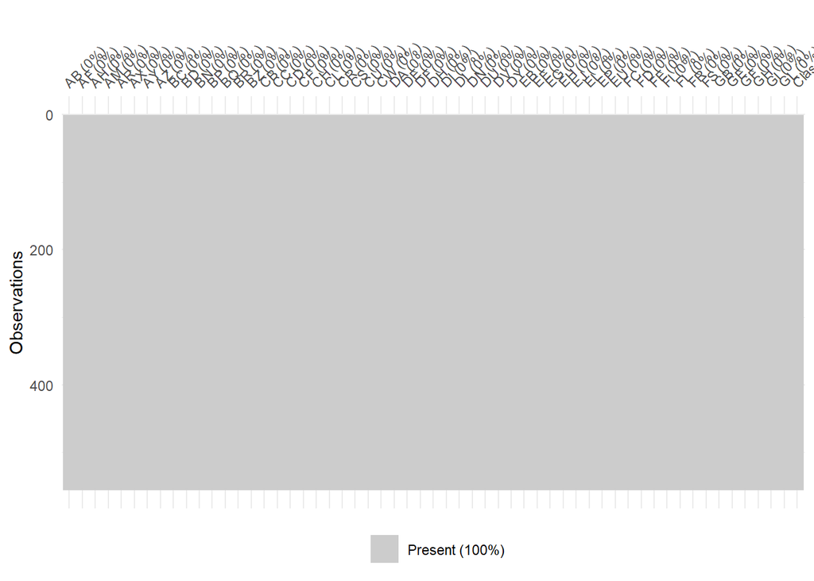

```r
vis_miss(df_train)
```

## Data Pre Processing

In order to properly use the data, we need to normalize it by scaling it.

We can now scale all the variables (except for the categorical one)

```r
df_numeric <- select(df_train, -c(EJ, Class))
df_fac <- select(df_train, c(EJ, Class))
df_scaled <- cbind(scale(df_numeric), df_fac)
```

As explained above, the dataset is heavily unbalanced w.r.t. the response.

In order to tackle this issue, we can apply an over sampling technique, using the library ROSE.

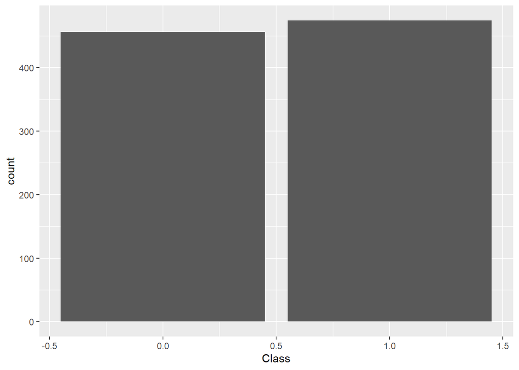

```r
library(ROSE)
data_balanced <- ovun.sample(Class ~ ., data = df_scaled, method = "over")$data
ggplot(data = data_balanced, aes(x = Class)) + geom_bar()
```

We can see that now the dataset is much more balanced, having a near 50/50 split between the two classes.

## Training and Validation

We can now split the training set into training and validation.

First, we remove the target variable from the training dataset, and save it in an appropriate new variable.

```r
target <- select(data_balanced, Class)
data_balanced <- select(data_balanced, -Class)
```

Then, we can split the training set by a 80/20 % split.

```r
sample <- sample(c(TRUE, FALSE), nrow(data_balanced), replace = TRUE, prob = c(0.8, 0.2))
x_train  <- data_balanced[sample, ]
x_val <- data_balanced[!sample, ]
y_train <- target[sample, ]
y_val <- target[!sample,]
```

# Models

We can try out different models to try and best predict the target variable.

## Decision Tree

First we try a tree model:

```r
library(tree)
tree_model <- tree(as.factor(y_train) ~., x_train)
tree_preds <- predict(tree_model, x_val, type = "class")
tree_table <- table(tree_preds , y_val)
tree_table
```

```
##           y_val
## tree_preds  0  1
##          0 93  3
##          1  9 89
```

Using these, we can calculate accuracy, precision, recall, and F1 score for our model.

```r
tree_accuracy <- (tree_table[1,1] + tree_table[2,2])/(tree_table[1,1] + tree_table[1,2] + tree_table[2,1] + tree_table[2,2])
tree_precision <- tree_table[1,1]/(tree_table[1,1] + tree_table[1,2])
tree_recall <- tree_table[1,1]/(tree_table[1,1] + tree_table[2,1])
tree_F1 <- 2 * (tree_precision * tree_recall)/(tree_precision + tree_recall)

tree_results <- data.frame(
  Metric = c("Accuracy", "Precision", "Recall", "F1 Score"),
  Value = c(tree_accuracy, tree_precision, tree_recall, tree_F1)
)
print(tree_results)
```

```
##      Metric     Value
## 1  Accuracy 0.9381443
## 2 Precision 0.9687500
## 3    Recall 0.9117647
## 4  F1 Score 0.9393939
```

Performance is already good, but we can try if cross-validation can help.

```r
cv_tree <- cv.tree(tree_model, FUN = prune.misclass)
cv_tree
```

```
## $size
##  [1] 20 19 16 15 13 10  8  6  4  3  2  1
##
## $dev
##  [1]  56  54  53  59  61  61  74  77  84 119 209 354
##
## $k
##  [1]  -Inf   0.0   2.0   3.0   3.5   4.0   6.0   7.0   8.5  37.0  90.0 145.0
##
## $method
## [1] "misclass"
##
## attr(,"class")
## [1] "prune"         "tree.sequence"
```

We can now plot the cross-validation error rate ($dev) as a function of size.

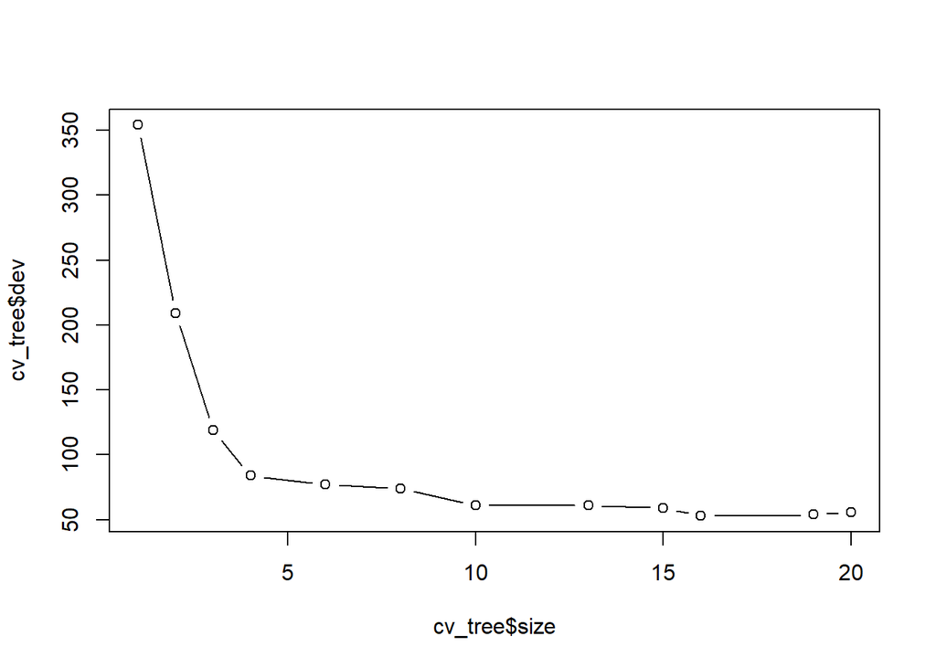

```r
plot(cv_tree$size, cv_tree$dev, type = "b")
```

We can see that the decision tree with 16 terminal nodes looks to be the best choice for our model, in terms of c-v error rate.

```r
tree_model_opt <- prune.tree(tree_model, best = 16)
tree_opt_preds <- predict(tree_model_opt, x_val, type = 'class')
tree_opt_table <- table(tree_opt_preds , y_val)
tree_opt_table
```

```
##               y_val
## tree_opt_preds  0  1
##              0 90  3
##              1 12 89
```

```r
tree_opt_accuracy <- (tree_opt_table[1,1] + tree_opt_table[2,2])/(tree_opt_table[1,1] + tree_opt_table[1,2] + tree_opt_table[2,1] + tree_opt_table[2,2])
tree_opt_precision <- tree_opt_table[1,1]/(tree_opt_table[1,1] + tree_opt_table[1,2])
tree_opt_recall <- tree_opt_table[1,1]/(tree_opt_table[1,1] + tree_opt_table[2,1])
tree_opt_F1 <- 2 * (tree_opt_precision * tree_opt_recall)/(tree_opt_precision + tree_opt_recall)

tree_opt_results <- data.frame(
  Metric = c("Accuracy", "Precision", "Recall", "F1 Score"),
  Value = c(tree_opt_accuracy, tree_opt_precision, tree_opt_recall, tree_opt_F1)
)
print(tree_opt_results)
```

```
##      Metric     Value
## 1  Accuracy 0.9226804
## 2 Precision 0.9677419
## 3    Recall 0.8823529
## 4  F1 Score 0.9230769
```

In this case, using c-v to prune the tree did not improve our results (it actually found a worse solution).

## Random Forest

The second model we test is a Random Forest, using sqrt(p) as the size of considered predictors at each random split.

```r
library(randomForest)

rf_model <- randomForest(as.factor(y_train) ~.,
                         data = x_train,
                         mtry = sqrt(58),
                         importance = TRUE)
rf_preds <- predict(rf_model,
                    newdata = x_val,
                    type = 'class')

rf_table <- table(rf_preds , y_val)
rf_table
```

```
##         y_val
## rf_preds  0  1
##        0 96  0
##        1  6 92
```

```r
rf_accuracy <- (rf_table[1,1] + rf_table[2,2])/(rf_table[1,1] + rf_table[1,2] + rf_table[2,1] + rf_table[2,2])
rf_precision <- rf_table[1,1]/(rf_table[1,1] + rf_table[1,2])
rf_recall <- rf_table[1,1]/(rf_table[1,1] + rf_table[2,1])
rf_F1 <- 2 * (rf_precision * rf_recall)/(rf_precision + rf_recall)

rf_results <- data.frame(
  Metric = c("Accuracy", "Precision", "Recall", "F1 Score"),
  Value = c(rf_accuracy, rf_precision, rf_recall, rf_F1)
)
print(rf_results)
```

```
##      Metric     Value
## 1  Accuracy 0.9690722
## 2 Precision 1.0000000
## 3    Recall 0.9411765
## 4  F1 Score 0.9696970
```

Random Forest has a higher score than the simpler decision tree model.

We can check what the most important variables are in the Random Forest model using a Variable Importance Plot.

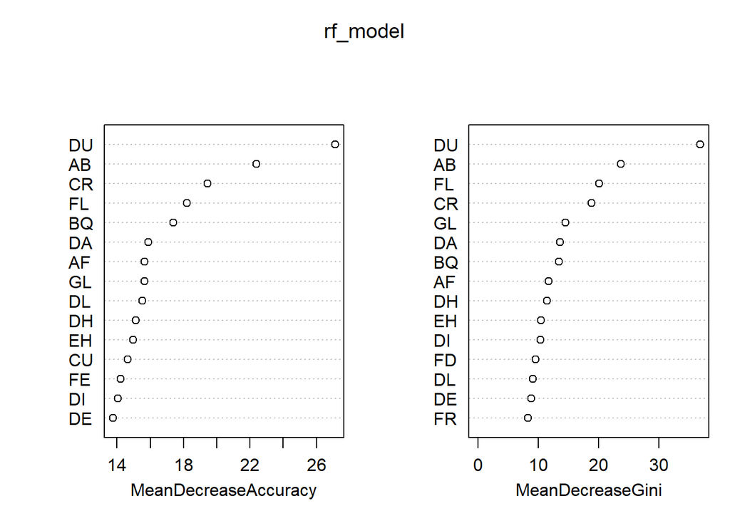

```r
varImpPlot(rf_model, n.var = 15)
```

By looking at both plots, we can see that the first 5 predictors seem to be the most important ones. In particular, DU and AB seem to be the two most important predictor for the Random Forest model.

## Boosting

As a third model, we can test the Boosting algorithm.

```r
library(gbm)

boost_model <- gbm(as.factor(y_train) ~.,
                   data = x_train,
                   distribution = 'multinomial', # for classification
                   shrinkage = 0.01,
                   n.trees = 500,
                   interaction.depth = 4)
boost_preds <- predict(object = boost_model,
                       newdata = x_val,
                       n.trees = 500,
                       type = 'response')

boost_preds = colnames(boost_preds)[apply(boost_preds, 1, which.max)]

boost_table <- table(boost_preds, y_val)
boost_table
```

```
##            y_val
## boost_preds  0  1
##           0 94  0
##           1  8 92
```

```r
boost_accuracy <- (boost_table[1,1] + boost_table[2,2])/(boost_table[1,1] + boost_table[1,2] + boost_table[2,1] + boost_table[2,2])
boost_precision <- boost_table[1,1]/(boost_table[1,1] + boost_table[1,2])
boost_recall <- boost_table[1,1]/(boost_table[1,1] + boost_table[2,1])
boost_F1 <- 2 * (boost_precision * boost_recall)/(boost_precision + boost_recall)

boost_results <- data.frame(
  Metric = c("Accuracy", "Precision", "Recall", "F1 Score"),
  Value = c(boost_accuracy, boost_precision, boost_recall, boost_F1)
)
print(boost_results)
```

```
##      Metric     Value
## 1  Accuracy 0.9587629
## 2 Precision 1.0000000
## 3    Recall 0.9215686
## 4  F1 Score 0.9591837
```

Boosting seems to have reached a higher performances compared to the simple decision tree model, but still lags behind the Random Forest model.

# Testing

After comparing the three different models, we can see that the best suited one for our dataset is the Random Forest.

Thus, we can now use this model to compute the Balanced Logarithmic Loss on the test set.

First, load the test data and perform the same pre-processing steps as above.

```r
df_test <- read.csv("test.csv")
df_test <- mutate(df_test, across(where(is.numeric), ~replace_na(., median(., na.rm=TRUE))))
df_test$EJ <- as.factor(df_test$EJ)
df_test_EJ <- select(df_test, EJ)
test_id <- select(df_test, Id)
true_labels <- select(df_test, Class)
df_test <- select(df_test, -c(X, Id, EJ, Class))
df_test <- cbind(scale(df_test), df_test_EJ)
```

Then we can predict the labels using our model. We are interested in the probability since we are computing the Balanced Logarithmic Loss.

```r
test_preds <- predict(rf_model,
                            newdata = df_test,
                            type = "prob")
```

If we print the test predictions, we can see that each new observation has two values, which represent the probability of belonging to either Class 0, or Class 1.

```r
head(test_preds)
```

```
##       0     1
## 1 0.712 0.288
## 2 0.676 0.324
## 3 0.816 0.184
## 4 0.886 0.114
## 5 0.670 0.330
## 6 0.580 0.420
```

Now we compute the Balanced Logarithmic Loss:
$$BLL =\frac{-\frac{1}{N_0}\sum_{i=1}^{N_0} y_{0i}log(p_{0i})
-\frac{1}{N_1}\sum_{i=1}^{N_1} y_{1i}log(p_{1i})}{2}$$

where:

- N_c is the number of observations of class *c*
- y_ci is 1 if observation *i* belongs to class *c*, 0 otherwise
- p_ci is the predicted probability that observation *i* belongs to class *c*

additionally, each predicted probability p is replaced with

$$max(min(p, 1-10^{-15}), 10^{-15})$$

in order to avoid extremes of the log function.

```r
N_0 = sum(1 - true_labels)
N_1 = sum(true_labels)
p_1 = pmax(pmin(test_preds, 1-1e-15), 1e-15)
p_0 = pmax(pmin(1 - test_preds, 1-1e-15), 1e-15)

log_loss_0 <- -1/N_0 * (sum((1 - true_labels)*log(p_0)))
log_loss_1 <- -1/N_1 * (sum(true_labels*log(p_1)))
BLL <- (log_loss_0 + log_loss_1)/2
```

The final result is

```r
BLL
```

```
## [1] 1.217885
```

finally, we can save our prediction results in a .csv file.

```r
class_0 <- test_preds[,1]
class_1 <- test_preds[,2]
results <- data.frame(Id = test_id, class_0 = class_0, class_1 = class_1)
write.csv(results, file = 'results.csv', row.names = FALSE, quote = FALSE)
```